# R Notebook

# Aims

Here I aim to demonstrate the application of SiMBA and reference tissue models on a simulated dataset

# Preparation

## Libraries

```r
library(lmerTest)
```

## Data

```r
modeldat <- readRDS("../RawData/simdata.rds")
```

# Data Exploration

## Main Dataset

This data consists of simulated data from 10 controls, before and after treatment with a placebo intervention (true effect = 0); as well as 10 patients before and after treatment with a real intervention (true effect = +0.04 in logBPnd). The patient group has a mean logBPnd of 0.08 less than the control group.

Each individual is defined by ID,, group membership is defined by Group, intervention is defined by Treatment, and each individual PET measurement is defined by PET.

```r
unique(modeldat$Group)
```

```
[1] "Control" "Patient"
```

Looking at the first PET measurement, let’s visualise the measured TACs.

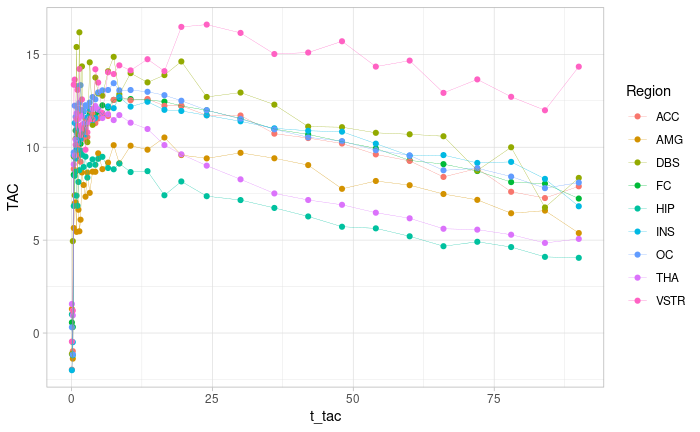

```r
dat_1 <- modeldat %>%
  filter(PET == PET[1])

ggplot(dat_1, aes(x=t_tac, y=TAC, colour=Region)) +
  geom_point() +
  geom_line(linewidth=0.1)
```

I have also included the true values, as if these TACs were measured without any error, shown here with the lines.

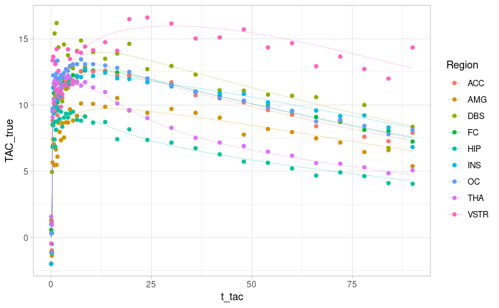

```r
ggplot(dat_1, aes(x=t_tac, y=TAC_true, colour=Region)) +
  geom_point(aes(y=TAC)) +
  geom_line(linewidth=0.1)
```

Lastly, I have included the reference region TAC from which these were generated, shown in black.

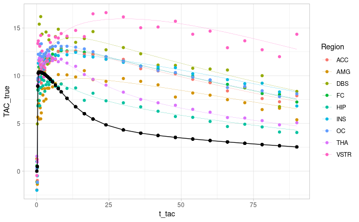

```r
ggplot(dat_1, aes(x=t_tac, y=TAC_true, colour=Region)) +
  geom_point(aes(y=TAC)) +
  geom_line(linewidth=0.1) +
  geom_point(aes(y = RefCBL_true), colour="black") +
  geom_line(aes(y = RefCBL_true), colour="black")
```

With SiMBA applied to reference tissue models, the reference region TAC must be fitted in advance. I will eventually include a reference region TAC along with the simulated data, but for now, I have just included another dataset with some reference region TACs to fit, shown below.

## Reference TACs

Here are some example reference region TACs.

```r
reftacs <- readRDS("../RawData/reftacs.rds")
```

And let’s visualise

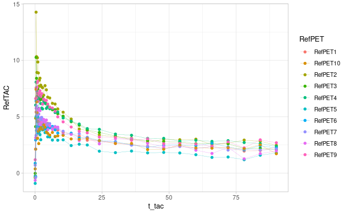

```r
ggplot(reftacs, aes(x=t_tac, y=RefTAC, colour=RefPET)) +
  geom_point() +
  geom_line(linewidth=0.1)
```

And here shown for one of the measurements, along with the true values shown with a line.

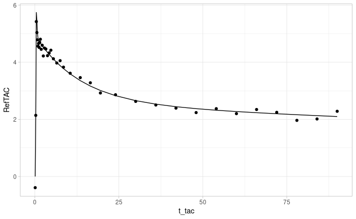

```r
reftacs %>%
  filter(RefPET == RefPET[1]) %>%
  ggplot(aes(x=t_tac, y=RefTAC)) +
  geom_point() +
  geom_line(aes(y=RefTAC_true), )
```

# Modelling

## RefTAC modelling

Before starting with SiMBA, we will need to fit the reference region TACs. Here, in the included RefTAC data, I will show how we can fit them. First, I recommend nesting the data for convenience.

```r
reftacs_nested <- reftacs %>%
  group_by(RefPET) %>%
  nest()

reftacs_nested
```

| RefPET | data |
| --- | --- |
| RefPET1 |  |
| RefPET2 |  |
| RefPET3 |  |
| RefPET4 |  |
| RefPET5 |  |
| RefPET6 |  |
| RefPET7 |  |
| RefPET8 |  |
| RefPET9 |  |
| RefPET10 |  |

Then, for fitting it, I have actually included the fitting function within `kinfitr` for convenience, called `feng_1tc_tac`. Because this function has more parameters than are reasonable, because our intention is describing the TAC rather than learning about its true underlying parameters, it can quite easily land in local minima. For this reason, the function is defined so that the model fits each TAC a lot of times with randomly selected starting parameters. This reduces the likelihood of getting poor fits. This can also be modified so that it’s parallelised using the `furrr` package.

```r
reftacs_nested <- reftacs_nested %>%
  mutate(reffit = future_map(data, ~kinfitr::feng_1tc_tac(t_tac = .x$t_tac,
                                                          tac = .x$RefTAC,
                                                          weights = .x$kfweights)))
```

Now let’s examine our fits (I strongly recommend giving them all a look-over to make sure that nothing went wrong).

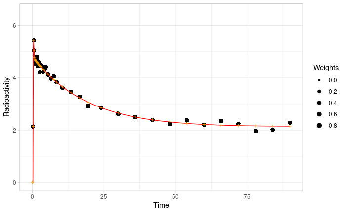

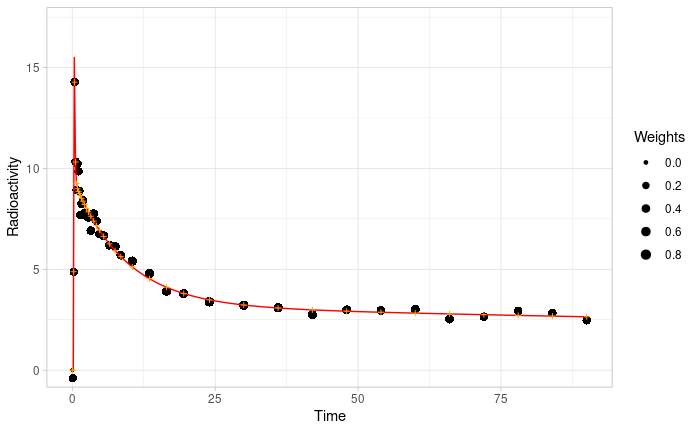

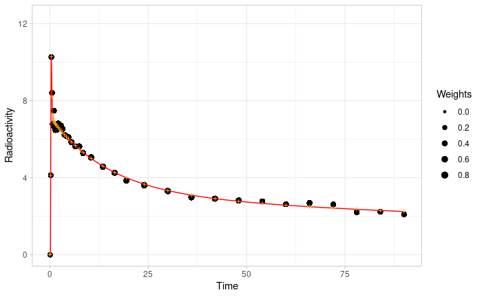

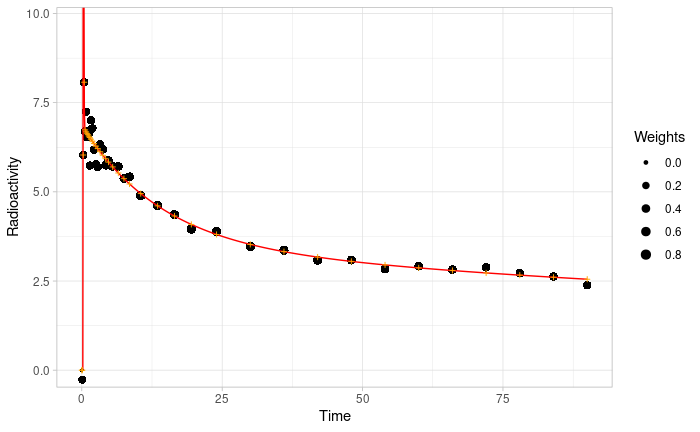

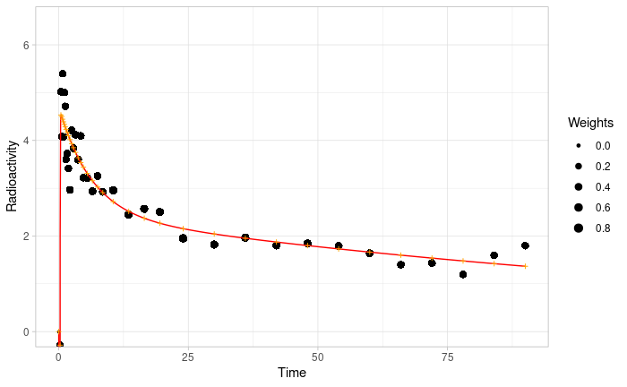

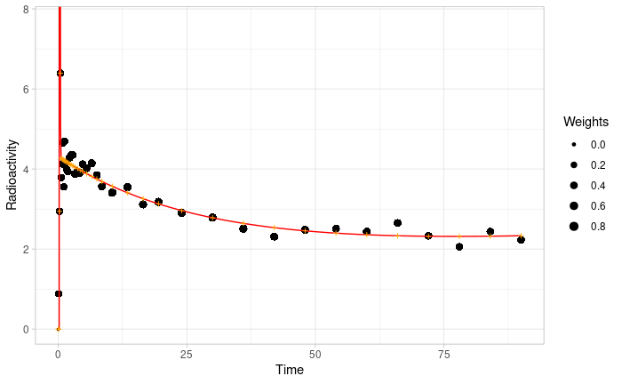

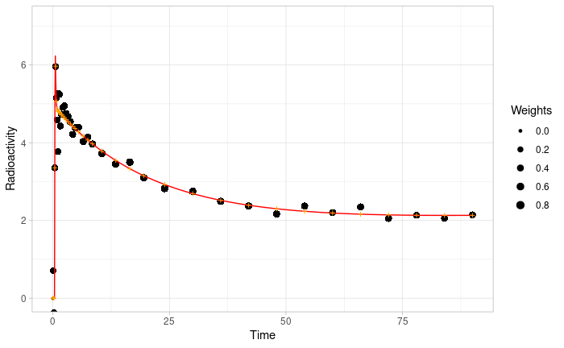

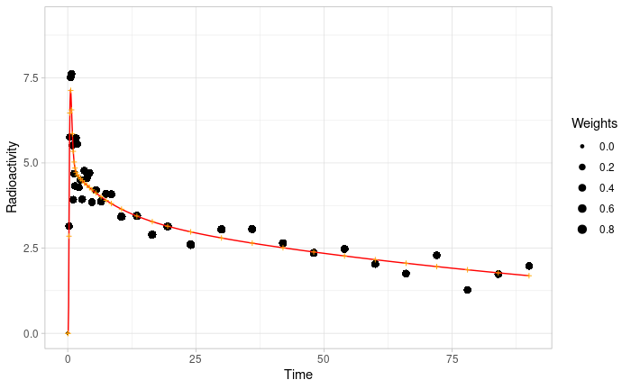

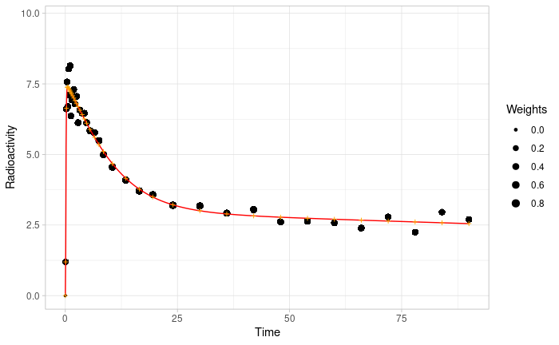

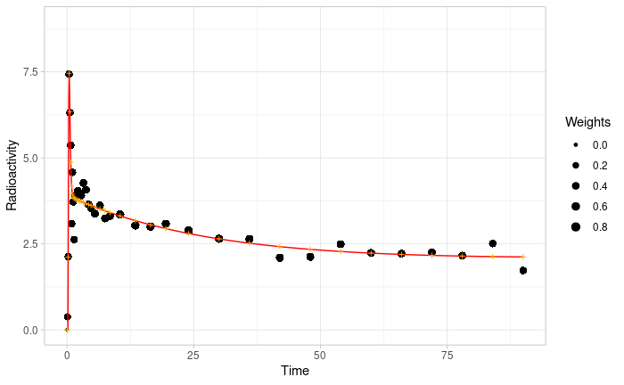

```r
map(reftacs_nested$reffit, plot)
```

These fits all look ok to me. Notably, the red line shows the fit, and the orange crosses show the points along the fits which correspond with the exact times of the data points.

Then we can extract the estimated parameter values

```r
refpar <- reftacs_nested %>%
  mutate(par = map(reffit, "par")) %>%
  select(RefPET, par) %>%
  unnest(par)

refpar
```

| RefPET | t0 | A | B | C | alpha | beta | gamma | Ph1 | Th1 |
| --- | --- | --- | --- | --- | --- | --- | --- | --- | --- |
| RefPET1 | 0.18921620 | 13744.984 | -1.068445e+04 | 0.07673600 | 14.583388 | 13.4598972 | -0.0005253839 | 1.3772799 | 0.051610310 |
| RefPET2 | 0.21697245 | -6479.679 | -4.646559e-01 | -981.20841700 | 14.041414 | 0.1113488 | 32.0566524906 | 1.4664068 | 0.002127584 |
| RefPET3 | 0.19471138 | 21860.586 | -1.743691e+04 | 0.08576690 | 14.228955 | 13.1069230 | 0.0038136057 | 2.3402604 | 0.067820560 |
| RefPET4 | 0.23498413 | 97657.177 | -3.164575e+03 | 0.10367289 | 45.665624 | 27.9814555 | 0.0034393873 | 2.2716840 | 0.071411125 |
| RefPET5 | 0.08185103 | -526764.828 | 9.569825e+03 | 0.10608096 | 60.768923 | 31.7838873 | 0.0065398943 | 3.5494650 | 0.159497090 |
| RefPET6 | 0.24622318 | 167698.492 | -2.575925e+03 | 0.01100576 | 63.470112 | 31.6216961 | -0.0028798432 | 5.8692650 | 0.034812013 |
| RefPET7 | 0.35898428 | 16519.381 | -9.299227e+03 | 0.03641736 | 18.476849 | 16.9179663 | -0.0013382851 | 2.4504379 | 0.046892727 |
| RefPET8 | 0.12622615 | 8294.084 | -1.453682e+04 | 0.47861631 | 6.405751 | 5.8964483 | 0.0081718303 | 0.8349380 | 0.121588465 |
| RefPET9 | 0.04415165 | 14982.561 | 9.021779e+01 | -91.88087349 | 18.071508 | 0.1643002 | 0.1594939525 | 0.1643714 | 0.001938213 |
| RefPET10 | 0.19304449 | 11015.443 | -9.231236e+03 | 0.04025218 | 10.321565 | 9.2742485 | -0.0009401688 | 1.6450124 | 0.034558057 |

Once we have our estimated parameters, we can join this to our TAC data ready for SiMBA modelling.

# TAC Modelling

## Reference Error Discussion

Now that we have our TACs, and our reftac parameter values, we can start to model the TACs themselves. With the simulated data, the fitted parameter values, as well as the true and fitted reference region TACs are already included, and we will use those. Let’s first visualise the first measurement’s true (black) and fitted (red) reference region TAC.

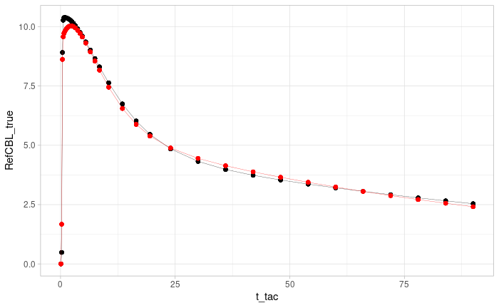

As we can see, the fitted RefTAC is not exactly thr same as the true RefTAC from which the TAC data are generated, but it’s reasonably close. But this will always be a source of some variance.

## Nonlinear Least Squares (NLS)

The usual way that PET researchers model TACs is to fit each TAC individually and independently. Usually, for fitting reference tissue models, we would simply interpolate the measurement reference region TAC. However, with SiMBA, we will use the fitted reference region. This is much faster because the convolution can be solved analytically. For comparison purposes, we can also implement the same model with NLS.

```r
Feng_reftac_expconv <- function(time,
                                A, B, C,
                                alpha, beta, gamma,
                                Ph1, Th1, lambda) {

  (Ph1*((A*(-1 + exp((-alpha + lambda)*time)))/((alpha - lambda)*(alpha - Th1)^(2)) +
          (alpha*A*(-1 + exp((-alpha + lambda)*time)*(1 + alpha*time - lambda*time)))/
          ((alpha - lambda)^(2)*(alpha - Th1)^(2)) +
          (B*(-1 + exp((-alpha + lambda)*time)))/((-alpha + lambda)*(alpha - Th1)) +
          (C*(-1 + exp((-alpha + lambda)*time)))/((-alpha + lambda)*(alpha - Th1)) +
          (B*(-1 + exp((-beta + lambda)*time)))/((beta - lambda)*(beta - Th1)) +
          (C*(-1 + exp((-gamma + lambda)*time)))/((gamma - lambda)*(gamma - Th1)) +
          (A*(-1 + exp(time*(lambda - Th1))))/((alpha - Th1)^(2)*(lambda - Th1)) +

          (A*(1 + exp((-alpha + lambda)*time)*(-1 - alpha*time + lambda*time))*Th1)/
          ((alpha - lambda)^(2)*(alpha - Th1)^(2)) +
          (B*(-1 + exp(time*(lambda - Th1))))/((lambda - Th1)*(-alpha + Th1)) +
          (C*(-1 + exp(time*(lambda - Th1))))/((lambda - Th1)*(-alpha + Th1)) -
          (B*(-1 + exp(time*(lambda - Th1))))/((lambda - Th1)*(-beta + Th1)) -
          (C*(-1 + exp(time*(lambda - Th1))))/((lambda - Th1)*(-gamma + Th1))))/
    exp(lambda*time)


}

srtm_smoothana_model <- function(time, t0,
                                 A, B, C,
                                 alpha, beta, gamma,
                                 Ph1, Th1,
                                 R1, k2prime, bp) {

  time <- time - t0

  k2 <- k2prime * R1

  a <- k2 - ((R1*k2) / (1+bp))
  b <- k2 / (1+bp)

  reftac = (time > 0) * (
    (Ph1*((B*(-1 + exp(time*(-alpha + Th1))))/(alpha - Th1) +
            (C*(-1 + exp(time*(-alpha + Th1))))/(alpha - Th1) +
            (B*(-1 + exp(time*(-beta + Th1))))/(-beta + Th1) +
            (C*(-1 + exp(time*(-gamma + Th1))))/(-gamma + Th1) +
            (A*(1 + exp(time*(-alpha + Th1))*(-1 - alpha*time + time*Th1)))/
            (alpha - Th1)^(2)))/exp(time*Th1)
  )

  (time > 0) * (
    # First term
    ( R1 * reftac ) +

      # Second term
      ( a * Feng_reftac_expconv(time,
                                A, B, C,
                                alpha, beta, gamma,
                                Ph1, Th1, b)
      )
  )

}

srtm_smoothana_logpar_model <- function(time, t0,
                                        A, B, C,
                                        alpha, beta, gamma,
                                        Ph1, Th1,
                                        logR1, logk2prime, logBPnd) {

  srtm_smoothana_model(time, t0,
                       A, B, C,
                       alpha, beta, gamma,
                       Ph1, Th1,
                       exp(logR1),
                       exp(logk2prime),
                       exp(logBPnd))

}
```

Now, let’s nest the data by each TAC…

```r
modeldat_nested <- modeldat %>%
  group_by(ID, Treatment, PET, Region) %>%
  nest()

modeldat_nested
```

| ID | PET | Treatment | Region | data |
| --- | --- | --- | --- | --- |
| Control_1 | Control_1_Control | Control | FC |  |
| Control_1 | Control_1_Control | Control | ACC |  |
| Control_1 | Control_1_Control | Control | AMG |  |
| Control_1 | Control_1_Control | Control | DBS |  |
| Control_1 | Control_1_Control | Control | HIP |  |
| Control_1 | Control_1_Control | Control | INS |  |
| Control_1 | Control_1_Control | Control | OC |  |
| Control_1 | Control_1_Control | Control | THA |  |
| Control_1 | Control_1_Control | Control | VSTR |  |
| Control_1 | Control_1_Placebo | Placebo | FC |  |

[output cut: 350 more lines]

… and fit the model

| ID | PET | Treatment | Region | data | R1 | k2prime | bp | logR1 | logk2prime | logBPnd |
| --- | --- | --- | --- | --- | --- | --- | --- | --- | --- | --- |
| Control_1 | Control_1_Control | Control | FC |  | 0.9852224 | 0.11325773 | 1.6171129 | -0.0148878604 | -2.1780892 | 0.4806423836 |
| Control_1 | Control_1_Control | Control | ACC |  | 0.9395960 | 0.12560585 | 1.5474745 | -0.0623053363 | -2.0746065 | 0.4366242417 |
| Control_1 | Control_1_Control | Control | AMG |  | 0.6519206 | 0.15328564 | 1.1000088 | -0.4278324517 | -1.8754521 | 0.0953181786 |
| Control_1 | Control_1_Control | Control | DBS |  | 1.1035222 | 0.11212736 | 1.8603880 | 0.0985070878 | -2.1881199 | 0.6207850808 |
| Control_1 | Control_1_Control | Control | HIP |  | 0.8145724 | 0.10377149 | 0.5085604 | -0.2050919583 | -2.2655640 | -0.6761713220 |
| Control_1 | Control_1_Control | Control | INS |  | 1.0082324 | 0.09674317 | 1.7308232 | 0.0081986648 | -2.3356955 | 0.5485971308 |
| Control_1 | Control_1_Control | Control | OC |  | 1.1449300 | 0.08934214 | 1.6795917 | 0.1353434686 | -2.4152820 | 0.5185507389 |
| Control_1 | Control_1_Control | Control | THA |  | 1.0584169 | 0.11821346 | 0.7796119 | 0.0567743126 | -2.1352633 | -0.2489590042 |
| Control_1 | Control_1_Control | Control | VSTR |  | 1.0770167 | 0.09922694 | 3.2089181 | 0.0741949391 | -2.3103457 | 1.1659338467 |
| Control_1 | Control_1_Placebo | Placebo | FC |  | 0.9958049 | 0.13605144 | 1.5538583 | -0.0042039394 | -1.9947222 | 0.4407410438 |

[output cut: 350 more lines]

Now we can compare our fitted parameters with the true parameters.

```r
modeldat_nls_compare <- left_join(modeldat_pars, modeldat_truepars) %>%
  select(ID, Treatment, PET, Region, starts_with("log"))
```

### Estimation

Now let’s view the correlations

| Region | logR1 | logk2prime | logBPnd |
| --- | --- | --- | --- |
| ACC | 0.8156241 | 0.67240413 | 0.9854400 |
| AMG | 0.6451711 | 0.47371581 | 0.9537769 |
| DBS | 0.4629215 | 0.08993022 | 0.8464627 |
| FC | 0.8881893 | 0.71421271 | 0.9911525 |
| HIP | 0.8147311 | 0.45541007 | 0.9240012 |
| INS | 0.7049388 | 0.58124817 | 0.9832845 |
| OC | 0.7916419 | 0.58599628 | 0.9935173 |
| THA | 0.8880620 | 0.44653578 | 0.9747936 |
| VSTR | 0.3989302 | 0.45452267 | 0.9650557 |

Seems to be doing a pretty ok job!

### Inference

Now, we can evaluate group differences and treatment effects using a mixed linear model.

```r
summary(nls_lme_mod)
```

```
Linear mixed model fit by REML. t-tests use Satterthwaite's method ['lmerModLmerTest']
Formula: logBPnd ~ 1 + Region + Group + Treatment + (1 | ID)
   Data: modeldat_pars

REML criterion at convergence: -192.3

Scaled residuals:
     Min       1Q   Median       3Q      Max
-2.61375 -0.65839  0.02755  0.70469  2.37552

Random effects:
 Groups   Name        Variance Std.Dev.
 ID       (Intercept) 0.06604  0.2570
 Residual             0.02416  0.1554
Number of obs: 360, groups:  ID, 20

Fixed effects:
                     Estimate Std. Error         df t value Pr(>|t|)
(Intercept)          0.108965   0.086075  21.752249   1.266   0.2189
RegionAMG           -0.186306   0.034755 330.000000  -5.361 1.56e-07 ***
RegionDBS            0.082041   0.034755 330.000000   2.361   0.0188 *
RegionFC            -0.023481   0.034755 330.000000  -0.676   0.4998
RegionHIP           -1.006964   0.034755 330.000000 -28.973  < 2e-16 ***
RegionINS           -0.052150   0.034755 330.000000  -1.500   0.1344
RegionOC             0.085188   0.034755 330.000000   2.451   0.0148 *
RegionTHA           -0.828643   0.034755 330.000000 -23.842  < 2e-16 ***
RegionVSTR           0.437663   0.034755 330.000000  12.593  < 2e-16 ***
GroupPatient        -0.065243   0.117235  18.723830  -0.557   0.5844
TreatmentPlacebo    -0.001802   0.023170 330.000000  -0.078   0.9380
TreatmentTreatment   0.039342   0.023170 330.000000   1.698   0.0905 .
---
Signif. codes:  0 ‘***’ 0.001 ‘**’ 0.01 ‘*’ 0.05 ‘.’ 0.1 ‘ ’ 1

Correlation of Fixed Effects:
            (Intr) RgnAMG RgnDBS RegnFC RgnHIP RgnINS RegnOC RgnTHA RgVSTR GrpPtn TrtmnP
RegionAMG   -0.202
RegionDBS   -0.202  0.500
RegionFC    -0.202  0.500  0.500
RegionHIP   -0.202  0.500  0.500  0.500
RegionINS   -0.202  0.500  0.500  0.500  0.500
RegionOC    -0.202  0.500  0.500  0.500  0.500  0.500
RegionTHA   -0.202  0.500  0.500  0.500  0.500  0.500  0.500
RegionVSTR  -0.202  0.500  0.500  0.500  0.500  0.500  0.500  0.500
GroupPatint -0.681  0.000  0.000  0.000  0.000  0.000  0.000  0.000  0.000
TretmntPlcb -0.135  0.000  0.000  0.000  0.000  0.000  0.000  0.000  0.000  0.099
TrtmntTrtmn  0.000  0.000  0.000  0.000  0.000  0.000  0.000  0.000  0.000 -0.099  0.000
```

## SiMBA

Now, for our SiMBA model, we must first define our specific predictors and our priors. First, we define one region as the comparison region for the fixed effects. We will use the frontal cortex for this purpose.

Then we need to define the pharmacokinetic model definition in STAN code. I’ve included both the SRTM and FRTM here, but we will use the SRTM.

```r
rtm_anaconv_stan = "
real Feng_reftac_expconv(real time, real A, real B, real C,
                       real alpha, real beta, real gamma,
                       real Ph1, real Th1, real lambda) {

    real out;

    out = (Ph1*((A*(-1 + exp((-alpha + lambda)*time)))/((alpha - lambda)*(alpha - Th1)^(2)) +
          (alpha*A*(-1 + exp((-alpha + lambda)*time)*(1 + alpha*time - lambda*time)))/
          ((alpha - lambda)^(2)*(alpha - Th1)^(2)) +
          (B*(-1 + exp((-alpha + lambda)*time)))/((-alpha + lambda)*(alpha - Th1)) +
          (C*(-1 + exp((-alpha + lambda)*time)))/((-alpha + lambda)*(alpha - Th1)) +
          (B*(-1 + exp((-beta + lambda)*time)))/((beta - lambda)*(beta - Th1)) +
          (C*(-1 + exp((-gamma + lambda)*time)))/((gamma - lambda)*(gamma - Th1)) +
          (A*(-1 + exp(time*(lambda - Th1))))/((alpha - Th1)^(2)*(lambda - Th1)) +

          (A*(1 + exp((-alpha + lambda)*time)*(-1 - alpha*time + lambda*time))*Th1)/
          ((alpha - lambda)^(2)*(alpha - Th1)^(2)) +
          (B*(-1 + exp(time*(lambda - Th1))))/((lambda - Th1)*(-alpha + Th1)) +
          (C*(-1 + exp(time*(lambda - Th1))))/((lambda - Th1)*(-alpha + Th1)) -
          (B*(-1 + exp(time*(lambda - Th1))))/((lambda - Th1)*(-beta + Th1)) -
          (C*(-1 + exp(time*(lambda - Th1))))/((lambda - Th1)*(-gamma + Th1))))/
    exp(lambda*time);

   return(out);

}
real frtm_model(real logR1, real logk2prime,
                    real logBPnd, real logk4,
                    real time, real t0,
                    real A, real B, real C,
                    real alpha, real beta, real gamma,
                    real Ph1, real Th1) {

  real R1;
  real k2prime;
  real BPnd;
  real k4;

  real k2;
  real k3;
  real s;
  real r;
  real q;
  real p;
  real d;
  real c;
  real b;
  real a;

  real pred;

  real reftac;
  real tcorr;

  R1 = exp(logR1);
  k2prime = exp(logk2prime);
  BPnd = exp(logBPnd);
  k4 = exp(logk4);

  k2 = k2prime * R1;
  k3 = BPnd * k4;
  s = k2 + k3 + k4;
  r = k2/R1;
  q = 4 * k2 * k4;
  p = sqrt(s^2 - q);
  d = (s - p)/2;
  c = (s + p)/2;
  b = (d - k3 - k4) * (d - r)/p;
  a = (k3 + k4 - c) * (c - r)/p;

  tcorr = time - t0;

  reftac = (tcorr > 0) * (
    (Ph1*((B*(-1 + exp(tcorr*(-alpha + Th1))))/(alpha - Th1) +
              (C*(-1 + exp(tcorr*(-alpha + Th1))))/(alpha - Th1) +
              (B*(-1 + exp(tcorr*(-beta + Th1))))/(-beta + Th1) +
              (C*(-1 + exp(tcorr*(-gamma + Th1))))/(-gamma + Th1) +
              (A*(1 + exp(tcorr*(-alpha + Th1))*(-1 - alpha*tcorr + tcorr*Th1)))/
              (alpha - Th1)^(2)))/exp(tcorr*Th1)
              );

  pred = R1 * (
    reftac +
    a * Feng_reftac_expconv(tcorr,
                          A, B, C,
                          alpha, beta, gamma,
                          Ph1, Th1, c) +
    (tcorr > 0) * b * Feng_reftac_expconv(tcorr,
                              A, B, C,
                              alpha, beta, gamma,
                              Ph1, Th1, d)
       );

  return(pred);

}

real srtm_model(real logR1, real logk2prime, real logBPnd,
                    real time, real t0,
                    real A, real B, real C,
                    real alpha, real beta, real gamma,
                    real Ph1, real Th1) {

  real R1;
  real k2prime;
  real BPnd;
  real k2;

  real a;
  real b;

  real pred;

  real reftac;
  real tcorr;

  R1 = exp(logR1);
  k2prime = exp(logk2prime);
  BPnd = exp(logBPnd);
  k2 = k2prime * R1;

  tcorr = time - t0;

  reftac = (tcorr > 0) * (
    (Ph1*((B*(-1 + exp(tcorr*(-alpha + Th1))))/(alpha - Th1) +
              (C*(-1 + exp(tcorr*(-alpha + Th1))))/(alpha - Th1) +
              (B*(-1 + exp(tcorr*(-beta + Th1))))/(-beta + Th1) +
              (C*(-1 + exp(tcorr*(-gamma + Th1))))/(-gamma + Th1) +
              (A*(1 + exp(tcorr*(-alpha + Th1))*(-1 - alpha*tcorr + tcorr*Th1)))/
              (alpha - Th1)^(2)))/exp(tcorr*Th1)
              );

  a = k2 - ((R1*k2) / (1+BPnd));
  b = k2 / (1+BPnd);

  // First term
  pred = ( R1 * reftac ) +

  // Second term
  (tcorr > 0) * ( a * Feng_reftac_expconv(tcorr,
                            A, B, C,
                            alpha, beta, gamma,
                            Ph1, Th1, b));

  return(pred);

}
"
```

Next, we define our predictors. For sigma, we have a couple of extra parameters: we include the duration of each frame, of which we have taken the natural logarithm and then centred around zero. We also have a region size, which we have also taken the natural logarithm of, and then centres around zero.

Now we define the prior. I have commented out the injected radioactivity, which I would usually include for real data.

And now we can fit the model. We could either simply run `brms`. But sometimes, we might prefer to generate the STAN code and STAN data to fit the model directly. This can be done as follows:

```r
sc <- make_stancode(simbasrtm_fit_formula,
                    family=gaussian(),
                    data = modeldat,
                    prior = simbasrtm_prior,
                    stanvars = stanvar(scode = rtm_anaconv_stan,
                                       block="functions"))
```

[output not shown]

… and then we could feed that into `rstan` or `cmdstanr`. I will just use `brms` directly here.

```r
simba_fit <- brms::brm(
    simbasrtm_fit_formula,
    family=gaussian(),
                    data = modeldat,
                    prior = simbasrtm_prior,
                    stanvars = stanvar(scode = rtm_anaconv_stan,
                                       block="functions"),
    backend = "cmdstanr", inits = 0, iter = 1000, warmup = 300,
    chains=3, cores=3, seed = 753273)

saveRDS(simba_fit, "../DerivedData/simba_fit.rds")
```

```r
print(simba_fit, digits=3)
```

```
 Family: gaussian
  Links: mu = identity; sigma = log
Formula: TAC ~ srtm_model(logR1, logk2prime, logBPnd, t_tac, t0, A, B, C, alpha, beta, gamma, Ph1, Th1)
         sigma ~ 1 + s(t_tac) + dur_logc + logRegSize_c + (1 | Region) + (1 | PET)
         logR1 ~ 1 + Region + (1 | k | ID) + (1 | l | PET:Region)
         logk2prime ~ 1 + (1 | m | Region) + (1 | k | ID) + (1 | l | PET:Region)
         logBPnd ~ 1 + Region + Group + Treatment + (1 | k | ID) + (1 | l | PET:Region)
   Data: modeldat (Number of observations: 13680)
  Draws: 3 chains, each with iter = 1000; warmup = 300; thin = 1;
         total post-warmup draws = 2100

Smooth Terms:
                    Estimate Est.Error l-95% CI u-95% CI  Rhat Bulk_ESS Tail_ESS
sds(sigma_st_tac_1)    9.562     2.451    6.200   15.666 1.001      383      747

Group-Level Effects:
~PET (Number of levels: 40)
                    Estimate Est.Error l-95% CI u-95% CI  Rhat Bulk_ESS Tail_ESS
sd(sigma_Intercept)    0.232     0.029    0.183    0.297 1.008      398      580

~Region (Number of levels: 9)
                         Estimate Est.Error l-95% CI u-95% CI  Rhat Bulk_ESS Tail_ESS
sd(sigma_Intercept)         0.163     0.037    0.107    0.253 1.004     1084     1290
sd(logk2prime_Intercept)    0.116     0.027    0.074    0.181 1.003     1276     1629

~ID (Number of levels: 20)
                                            Estimate Est.Error l-95% CI u-95% CI  Rhat Bulk_ESS Tail_ESS
sd(logR1_Intercept)                            0.080     0.013    0.060    0.108 1.006      376      693
sd(logk2prime_Intercept)                       0.139     0.022    0.101    0.189 1.002      527      969
sd(logBPnd_Intercept)                          0.264     0.046    0.192    0.368 1.003      536      919
cor(logR1_Intercept,logk2prime_Intercept)     -0.753     0.106   -0.906   -0.501 1.001      632     1240
cor(logR1_Intercept,logBPnd_Intercept)         0.471     0.170    0.093    0.752 1.002      547      771
cor(logk2prime_Intercept,logBPnd_Intercept)   -0.305     0.198   -0.638    0.118 1.001      543      747

~PET:Region (Number of levels: 360)
                                            Estimate Est.Error l-95% CI u-95% CI  Rhat Bulk_ESS Tail_ESS
sd(logR1_Intercept)                            0.045     0.003    0.040    0.050 1.004      800     1441
sd(logk2prime_Intercept)                       0.059     0.006    0.049    0.071 1.003      717     1213
sd(logBPnd_Intercept)                          0.128     0.005    0.119    0.138 1.003      642     1290
cor(logR1_Intercept,logk2prime_Intercept)      0.055     0.114   -0.166    0.276 1.001      662     1366
```

[output cut: 20 more lines]

```
logBPnd_RegionINS            -0.020     0.030   -0.083    0.036 1.002      359      454
logBPnd_RegionOC              0.110     0.031    0.046    0.171 1.007      265      393
logBPnd_RegionTHA            -0.792     0.031   -0.855   -0.734 1.002      355      588
logBPnd_RegionVSTR            0.473     0.031    0.409    0.531 1.005      356      606
logBPnd_GroupPatient         -0.038     0.075   -0.189    0.105 1.003      752      978
logBPnd_TreatmentPlacebo      0.005     0.017   -0.029    0.039 1.000      643     1190
logBPnd_TreatmentTreatment    0.033     0.018   -0.002    0.067 1.003      965     1239
sigma_Intercept              -0.726     0.068   -0.860   -0.599 1.003      370      859
sigma_dur_logc               -0.177     0.042   -0.260   -0.095 1.002     2378     1604
sigma_logRegSize_c           -0.306     0.035   -0.376   -0.238 1.001     1100     1418
sigma_st_tac_1              -24.705     1.419  -27.491  -21.951 1.000     2342     1700

Draws were sampled using sample(hmc). For each parameter, Bulk_ESS
and Tail_ESS are effective sample size measures, and Rhat is the potential
scale reduction factor on split chains (at convergence, Rhat = 1).
```